# Supplementary Code 1

2/1/2016

## Load METABRIC Discovery dataset and essential packages

```r
setwd("~/vesselNormalization")
load("~/rstudio/lintian/metabric.exp.RData") # load METABRIC Discovery Dataset; you need apply to the access to the dataset
load("~/vesselNormalization/data/GO0001525_Angiogenesis.RData") # load 377 genes in angiogenesis pathway (GO:0001525)
library(limma) ## package for gene differential expression analysis
```

The gene expression information is stored in **metabric.d.exp**; row: patient/sample ids; col: gene names The patient annotation information is stored in **metabric.d.ann**; row: patient/sample ids; col: clinical parameters

## Select Patients

Only patients who were survived or died of cancer are kept. Patients whose survival information is lost or were not died of cancer are removed.

The patients who were alived were relabeled as ‘a’; the patients who died of cancer were relabeled with ‘dds’ (disease specific death).

```r
selected_patient.d <- which(metabric.d.ann$last_follow_up_status == "a" | metabric.d.ann$last_follow_up_status == "d-d.s.")
selected_patient.d.exp <- metabric.d.exp[selected_patient.d, angiogenesis]
selected_patient.d.ann <- metabric.d.ann[selected_patient.d, ]
selected_patient.d.ann$last_follow_up_status <- ifelse(selected_patient.d.ann$last_follow_up_status=="d-d.s.", "dds", "a")
```

## Differential Genes Selection

```r
survival <- factor(selected_patient.d.ann$last_follow_up_status)
design <- model.matrix(~0+survival) # Design matrix
contrast.matrix <- makeContrasts(contrasts="survivala - survivaldds", levels=design) # Make contrasts
fit <- lmFit(t(selected_patient.d.exp), design) # Linear model fitting
fit1 <- contrasts.fit(fit, contrast.matrix)
fit2 <- eBayes(fit1) # Bayes test
dif <- topTable(fit2, coef="survivala - survivaldds", n=nrow(fit2), adjust.method="fdr") # calculate the fold change, p value and false discovery rate (fdr)
dif <- dif[dif[, "adj.P.Val"]<0.01, ] # keep genes whose false discovery rate is below 0.01

# Get GPAGs (up-regulated in patients whose survival status is 'a': survivala - survivaldds > 0)
GPAGs <- subset(dif, logFC > 0)
GPAGs <- GPAGs[order(GPAGs$logFC, decreasing = TRUE), ]
GPAGs
```

```
##              logFC   AveExpr        t      P.Value    adj.P.Val          B
## ANG     1.09620531 32.958620 4.621624 4.430671e-06 9.279794e-05  3.8240152
## CXCL12  1.03157376 24.070528 5.679872 1.880817e-08 1.181780e-06  8.9822608
## C3      0.77043298 21.125415 5.159689 3.115236e-07 1.067676e-05  6.3228934
## CX3CR1  0.67123309 13.434432 6.097140 1.672097e-09 2.101268e-07 11.2851169
## CDC42   0.46975428 36.303919 5.781706 1.056319e-08 9.005428e-07  9.5304630
## TGFBR2  0.46899310 23.477272 4.296098 1.950022e-05 3.341628e-04  2.4387320
## CTNNB1  0.36999940 22.188119 4.017815 6.422594e-05 8.647564e-04  1.3311038
## CCR2    0.36721490 34.010996 3.966362 7.945733e-05 9.675174e-04  1.1340968
## CAV1    0.34901853 15.282712 3.815213 1.464471e-04 1.673047e-03  0.5695049
## PTGS2   0.34503069 12.170618 3.596410 3.422423e-04 3.300110e-03 -0.2103021
## SRPK2   0.34443666 18.600027 5.579594 3.290682e-08 1.559573e-06  8.4512070
## IL1B    0.30140984  6.675316 5.578567 3.309439e-08 1.559573e-06  8.4458136
## CYR61   0.26449482  8.548237 3.193546 1.459843e-03 9.655454e-03 -1.5292449
## KLF4    0.23818075 12.733351 3.228682 1.293838e-03 8.710301e-03 -1.4202705
## CASP8   0.22422396 22.289121 5.005699 6.835325e-07 1.986728e-05  5.5813406
## SCG2    0.22149281  6.033032 3.374804 7.739177e-04 5.610903e-03 -0.9546362
## EGR3    0.21731945 12.178181 5.186636 2.709223e-07 1.021377e-05  6.4548206
## JUN     0.21382693  9.537458 3.531187 4.371371e-04 3.773805e-03 -0.4341393
## TNFSF12 0.20640528 13.404265 5.760159 1.194354e-08 9.005428e-07  9.4137192
## NR4A1   0.18220834 16.471791 3.309490 9.760767e-04 6.814462e-03 -1.1652460
## KRIT1   0.17694575 19.754947 3.966056 7.955713e-05 9.675174e-04  1.1329356
## CYSLTR1 0.15914796  6.424753 4.118886 4.199226e-05 6.332433e-04  1.7251759
## FGF10   0.15804410  5.483526 4.189439 3.104556e-05 5.088771e-04  2.0058184
## HHEX    0.14052389  6.437334 3.516645 4.614113e-04 3.773805e-03 -0.4835043
## ROCK1   0.14023908 11.313445 4.760667 2.286341e-06 5.387192e-05  4.4449247
## GPX1    0.13212230 16.710953 3.433660 6.258159e-04 4.814951e-03 -0.7614254
## EMCN    0.12647158  6.167770 3.590369 3.501443e-04 3.300110e-03 -0.2311999
## S1PR1   0.10614574  6.414122 3.383953 7.489349e-04 5.536245e-03 -0.9248159
## ECSCR   0.09979983  5.955791 3.777043 1.703474e-04 1.888852e-03  0.4302662
## PLCD3   0.07951155  5.695342 3.551123 4.057944e-04 3.731329e-03 -0.3661406
```

```r
# Get PPAGs (down-regulated in patients whose survival status is 'a': survivala - survivaldds < 0)
PPAGs <- subset(dif, logFC < 0)
PPAGs <- PPAGs[order(PPAGs$logFC, decreasing = FALSE), ]
PPAGs
```

```
##                logFC   AveExpr         t      P.Value    adj.P.Val
## ADAM15   -0.64181552 26.484232 -4.783997 2.042694e-06 5.206035e-05
## GPR56    -0.61666535 25.744752 -5.439708 7.077532e-08 2.964700e-06
## ERBB2    -0.47390705 21.602820 -4.168777 3.393221e-05 5.330184e-04
## VEGFA    -0.34153699 18.585787 -4.063420 5.308038e-05 7.411594e-04
## GPI      -0.29601446  9.710212 -7.164641 1.758554e-12 6.629748e-10
## MYH9     -0.24766451 23.343624 -3.870412 1.174178e-04 1.383328e-03
## SPHK1    -0.21188285 12.851938 -4.078041 4.991406e-05 7.237538e-04
## COL4A1   -0.21149840 10.927878 -4.781116 2.071367e-06 5.206035e-05
## MED1     -0.20554225  7.027548 -3.713460 2.184943e-04 2.226280e-03
## RBM15    -0.19681157  8.115803 -6.834518 1.621170e-11 3.055906e-09
## ADAM8    -0.19046801  6.609275 -4.639193 4.079196e-06 9.046217e-05
## CXCL17   -0.18255546  5.890874 -3.313324 9.629701e-04 6.814462e-03
## IL18     -0.17844080 12.360934 -4.531755 6.733266e-06 1.336022e-04
## WNT7B    -0.17640769 17.154539 -3.287130 1.055859e-03 7.237432e-03
## EPHB3    -0.17185581  6.853022 -3.461432 5.655238e-04 4.441718e-03
## ROCK2    -0.16749742 20.236937 -3.618598 3.146294e-04 3.121455e-03
## SHB      -0.16135656  7.195542 -5.005250 6.850786e-07 1.986728e-05
## ITGA5    -0.15991861  8.062800 -3.748711 1.904143e-04 2.051035e-03
## COL4A2   -0.15545978  7.800267 -3.977921 7.576337e-05 9.675174e-04
## ANGPT2   -0.13804893  7.111743 -3.511398 4.704743e-04 3.773805e-03
## E2F7     -0.12162161  5.935547 -3.736038 2.000936e-04 2.095424e-03
## ADM2     -0.11461066  6.931564 -3.519568 4.564332e-04 3.773805e-03
## NAA15    -0.11450594  6.714169 -4.356627 1.490974e-05 2.676653e-04
## TNFRSF1A -0.10620631  9.351152 -3.530623 4.380554e-04 3.773805e-03
## PGF      -0.07455840  5.850239 -3.527169 4.437210e-04 3.773805e-03
## PLXDC1   -0.06779789  5.716051 -4.438802 1.030260e-05 1.942039e-04
## TGFBR1   -0.04405754  5.563719 -3.391624 7.285680e-04 5.493403e-03
##                   B
## ADAM15    4.5508103
## GPR56     7.7250171
## ERBB2     1.9231605
## VEGFA     1.5077521
## GPI      17.8434167
## MYH9      0.7732454
## SPHK1     1.5647947
## COL4A1    4.5377100
## MED1      0.2013291
## RBM15    15.7147476
## ADAM8     3.9015079
## CXCL17   -1.1529922
## IL18      3.4319747
## WNT7B    -1.2364258
## EPHB3    -0.6691340
## ROCK2    -0.1332517
## SHB       5.5792106
## ITGA5     0.3277922
## COL4A2    1.1781449
## ANGPT2   -0.5012660
## E2F7      0.2821937
## ADM2     -0.4735976
## NAA15     2.6890267
## TNFRSF1A -0.4360567
## PGF      -0.4477970
## PLXDC1    3.0341693
## TGFBR1   -0.8997519
```

## Visualization of GPAGs and PPAGs Using Heatmap

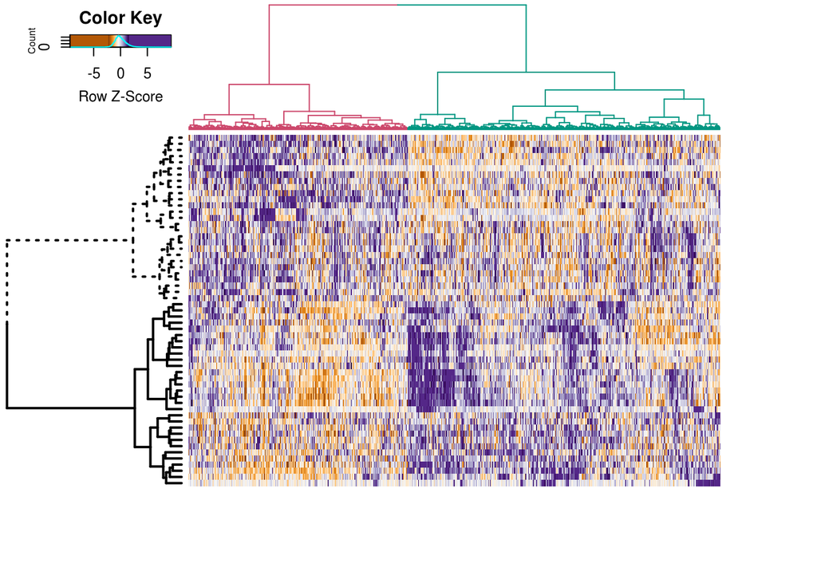

```r
library(gplots) ## For plot the heatmap
library(amap) ## For calculate the distance
library(dendextend) ## For draw the dendrogram
library(RColorBrewer)
select.ang.genes <- c(rownames(GPAGs), rownames(PPAGs)) ## combine GPAG names and PPAG names
## Row Cluster Labeling
row_dist <- Dist(t(selected_patient.d.exp[, select.ang.genes]), method="spearman")
rdend <- as.dendrogram(hclust(row_dist, method="ward.D"))
rowv <- rdend %>% set("branches_lwd", 2) %>%  set("by_labels_branches_lty", value=rownames(PPAGs), TF_values = c(3,Inf))
## Column Cluster Labeling
col_dist <- Dist(selected_patient.d.exp[, select.ang.genes], method="kendall")
colv <- color_branches(as.dendrogram(hclust(col_dist, method="ward.D")), k=2)

hmcol <- c(rep("#B35806", 90), colorRampPalette(brewer.pal(11, "PuOr"))(50), rep("#542788", 100))

heatmap.2(t(selected_patient.d.exp[, select.ang.genes]), col=hmcol, Rowv=rowv, Colv=colv, trace = "none", scale ="row", labRow=NA, labCol=NA, keysize = 1.2, key.title="Color Key")
```

## Survival Analysis on Two Clusters in the Heatmap

```r
library(survival)
patient.label <- cutree(hclust(col_dist, method="ward.D"), k=2) ## Get labeling information of the two clusters in the heatmap
survdiff(Surv(selected_patient.d.ann$T/30, selected_patient.d.ann$DSS) ~ patient.label) # p = 4.47e-09
```

```
## Call:
## survdiff(formula = Surv(selected_patient.d.ann$T/30, selected_patient.d.ann$DSS) ~
##     patient.label)
##
##                   N Observed Expected (O-E)^2/E (O-E)^2/V
## patient.label=1 475      109      155      13.8      34.4
## patient.label=2 333      151      105      20.5      34.4
##
##  Chisq= 34.4  on 1 degrees of freedom, p= 4.47e-09
```

```r
coxph(Surv(selected_patient.d.ann$T/30, selected_patient.d.ann$DSS) ~ patient.label) # Hazard Ratio > 2
```

```
## Call:
## coxph(formula = Surv(selected_patient.d.ann$T/30, selected_patient.d.ann$DSS) ~
##     patient.label)
##
##                coef exp(coef) se(coef)    z       p
## patient.label 0.722     2.058    0.126 5.74 9.4e-09
##
## Likelihood ratio test=33.5  on 1 df, p=7.01e-09
## n= 808, number of events= 260
```

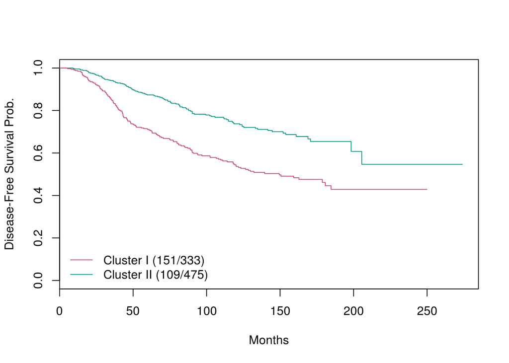

```r
plot(survfit(Surv(selected_patient.d.ann$T/30, selected_patient.d.ann$DSS) ~ patient.label), col=c("#009681", "#CC476B"), lty=1, lwd=1, xlab = "Months", ylab = "Disease-Free Survival Prob.", ylim=c(0, 1))
legend("bottomleft", c("Cluster I (151/333)", "Cluster II (109/475)"), col=c("#CC476B", "#009681"), lty=1, bty = "n", lwd=1)
```

## Test the ($\sum$GPAGs - $\sum$PPAGs) in METABRIC Validation Dataset

The gene expression information is stored in **metabric.v.exp**; row: patient/sample ids; col: gene names The patient annotation information is stored in **metabric.v.ann**; row: patient/sample ids; col: clinical parameters

```r
combineAng.vScore <- apply(metabric.v.exp[, rownames(GPAGs)], 1, sum) - apply(metabric.v.exp[, rownames(PPAGs)], 1, sum)
combineAng.vGroup <- cut(combineAng.vScore, breaks = quantile(combineAng.vScore, probs = seq(from = 0, to = 1, by = 1/3)), labels = c("low", "medium", "high"))
combineAng.vGroup[is.na(combineAng.vGroup)] = "low"
combineAng.vGroup <- factor(combineAng.vGroup, levels=c("high", "medium", "low"))
survdiff(Surv(metabric.v.ann$T/30, metabric.v.ann$DSS) ~ combineAng.vGroup) # p = 7.49e-06
```

```
## Call:
## survdiff(formula = Surv(metabric.v.ann$T/30, metabric.v.ann$DSS) ~
##     combineAng.vGroup)
##
## n=991, 4 observations deleted due to missingness.
##
##                            N Observed Expected (O-E)^2/E (O-E)^2/V
## combineAng.vGroup=high   329       50     75.7     8.729     12.75
## combineAng.vGroup=medium 330       75     83.5     0.871      1.32
## combineAng.vGroup=low    332      121     86.8    13.510     21.30
##
##  Chisq= 23.6  on 2 degrees of freedom, p= 7.49e-06
```

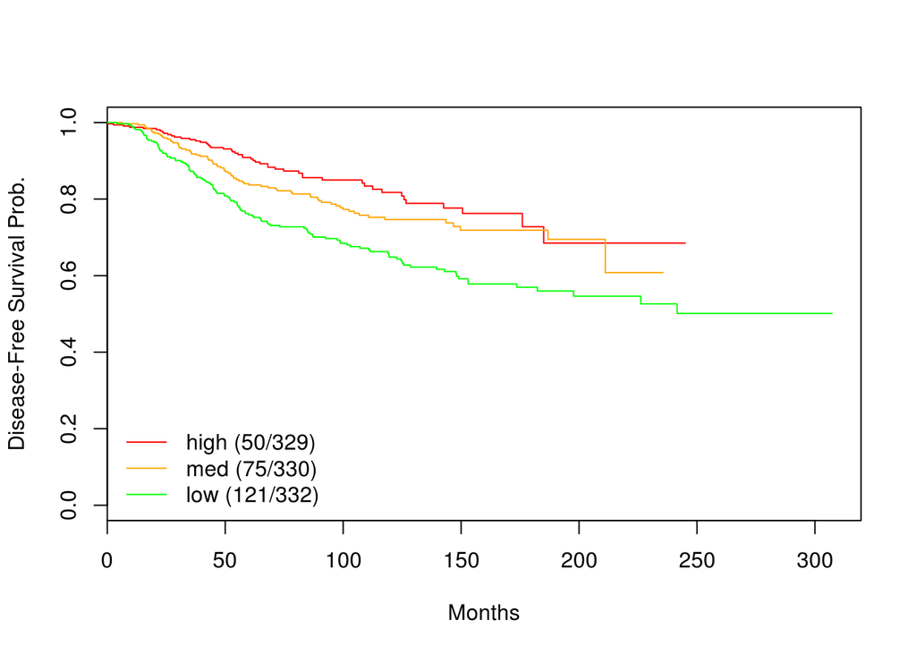

```r
plot(survfit(Surv(metabric.v.ann$T/30, metabric.v.ann$DSS) ~ combineAng.vGroup), col=c("red", "orange", "green"), lty=1, lwd=1, xlab = "Months", ylab = "Disease-Free Survival Prob.", ylim=c(0, 1))
legend("bottomleft", c("high (50/329)", "med (75/330)", "low (121/332)"), col=c("red", "orange", "green"), lty=1, bty = "n", lwd=1)
```

## Test the ($\sum$GPAGs - $\sum$PPAGs) for Relapse in (GSE1456)

```r
load("data/gse1456.RData") ## Used processed GSE1456.RData
```

The gene expression information is stored in **gse1456.exp**; row: gene names; col: patient/sample ids The patient annotation information is stored in **gse1456.ann**; row: patient/sample ids; col: clinical parameters

```r
GPAGs_gse1456 <- rownames(GPAGs)[rownames(GPAGs) %in% rownames(gse1456.exp)]
PPAGs_gse1456 <- rownames(PPAGs)[rownames(PPAGs) %in% rownames(gse1456.exp)]
gse1456.combine <- apply(gse1456.exp[GPAGs_gse1456, ], 2, sum) - apply(gse1456.exp[PPAGs_gse1456, ], 2, sum)
gse1456.combine.group <- cut(gse1456.combine, breaks = quantile(gse1456.combine, probs = seq(from = 0, to = 1, by = 1/3)), labels = c("low", "medium", "high"))
gse1456.combine.group[is.na(gse1456.combine.group)] = "low"
survdiff(Surv(gse1456.ann$RFS, gse1456.ann$Relapse) ~ gse1456.combine.group) # p = 6.89e-05
```

```
## Call:
## survdiff(formula = Surv(gse1456.ann$RFS, gse1456.ann$Relapse) ~
##     gse1456.combine.group)
##
##                               N Observed Expected (O-E)^2/E (O-E)^2/V
## gse1456.combine.group=low    53       24     11.7     13.01     18.45
## gse1456.combine.group=medium 53       10     13.7      1.02      1.56
## gse1456.combine.group=high   53        6     14.6      5.05      7.96
##
##  Chisq= 19.2  on 2 degrees of freedom, p= 6.89e-05
```

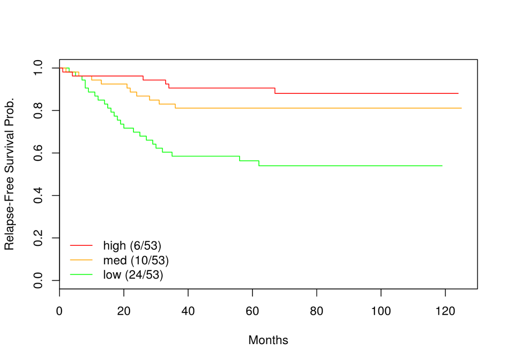

```r
plot(survfit(Surv(gse1456.ann$RFS, gse1456.ann$Relapse) ~ gse1456.combine.group), col=c("green", "orange", "red"), lty=1, lwd=1, xlab = "Months", ylab = "Relapse-Free Survival Prob.", ylim=c(0, 1))
legend("bottomleft", c("high (6/53)", "med (10/53)", "low (24/53)"), col=c("red", "orange", "green"), lty=1, bty = "n", lwd=1)
```

## Test the ($\sum$GPAGs - $\sum$PPAGs) for Distant Metastasis in (GSE2990)

```r
load("data/gse2990.RData")
```

The gene expression information is stored in **gse2990.exp**; row: gene names; col: patient/sample ids The patient annotation information is stored in **gse2990.ann**; row: patient/sample ids; col: clinical parameters

```r
GPAGs_gse2990 <- rownames(GPAGs)[rownames(GPAGs) %in% rownames(gse2990.exp)]
PPAGs_gse2990 <- rownames(PPAGs)[rownames(PPAGs) %in% rownames(gse2990.exp)]
gse2990.combine <- apply(gse2990.exp[GPAGs_gse2990, ], 2, sum) - apply(gse2990.exp[PPAGs_gse2990, ], 2, sum)
gse2990.combine.group <- cut(gse2990.combine, breaks = quantile(gse2990.combine, probs = seq(from = 0, to = 1, by = 1/3)), labels = c("low", "medium", "high"))
gse2990.combine.group[is.na(gse2990.combine.group)] = "low"
survdiff(Surv(gse2990.ann$time.dmfs*12, gse2990.ann$event.dmfs) ~ gse2990.combine.group) # p = 0.0022
```

```
## Call:
## survdiff(formula = Surv(gse2990.ann$time.dmfs * 12, gse2990.ann$event.dmfs) ~
##     gse2990.combine.group)
##
## n=179, 10 observations deleted due to missingness.
##
##                               N Observed Expected (O-E)^2/E (O-E)^2/V
## gse2990.combine.group=low    60       22     12.0     8.336     12.01
## gse2990.combine.group=medium 60       10     13.7     0.981      1.49
## gse2990.combine.group=high   59        8     14.3     2.803      4.41
##
##  Chisq= 12.2  on 2 degrees of freedom, p= 0.0022
```

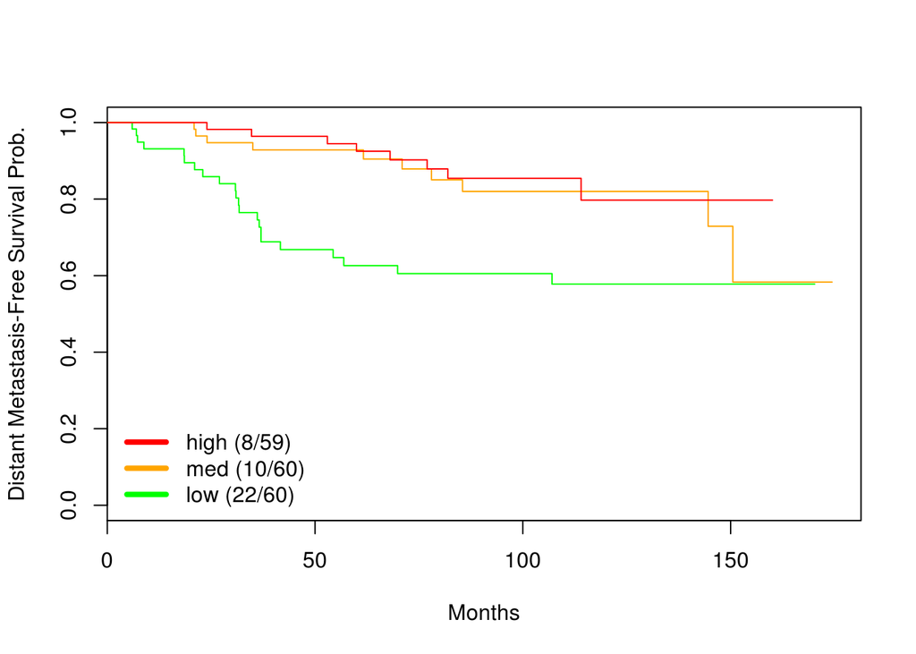

```r
plot(survfit(Surv(gse2990.ann$time.dmfs*12, gse2990.ann$event.dmfs) ~ gse2990.combine.group), col=c("green", "orange", "red"), lty=1, lwd=1, xlab = "Months", ylab = "Distant Metastasis-Free Survival Prob.", ylim=c(0, 1))
legend("bottomleft", c("high (8/59)", "med (10/60)", "low (22/60)"), col=c("red", "orange", "green"), lty=1, bty = "n", lwd=4)
```

## Correlation of GPAGs and PPAGs with T Cell Activation

To test the correlation of GPAGs, PPAGs with T cell activation, we used the samples in the combined METABRIC dataset (Discovery and Validation).

```r
library(LSD)
load("data/GO0042110_TcellActivation.RData")

## Correlation between GPAGs and TCR activation
cor.test(apply(metabric.a.exp[, rownames(GPAGs)], 1, sum), apply(metabric.a.exp[, GO0042110], 1, sum))
```

```
##
##  Pearson's product-moment correlation
##
## data:  apply(metabric.a.exp[, rownames(GPAGs)], 1, sum) and apply(metabric.a.exp[, GO0042110], 1, sum)
## t = 22.966, df = 1990, p-value < 2.2e-16
## alternative hypothesis: true correlation is not equal to 0
## 95 percent confidence interval:
##  0.4223038 0.4917659
## sample estimates:
##       cor
## 0.4577331
```

```r
## Correlation between PPAGs and TCR activation
cor.test(apply(metabric.a.exp[, rownames(PPAGs)], 1, sum), apply(metabric.a.exp[, GO0042110], 1, sum))
```

```
##
##  Pearson's product-moment correlation
##
## data:  apply(metabric.a.exp[, rownames(PPAGs)], 1, sum) and apply(metabric.a.exp[, GO0042110], 1, sum)
## t = -0.0004873, df = 1990, p-value = 0.9996
## alternative hypothesis: true correlation is not equal to 0
## 95 percent confidence interval:
##  -0.04392978  0.04390798
## sample estimates:
##           cor
## -1.092367e-05
```

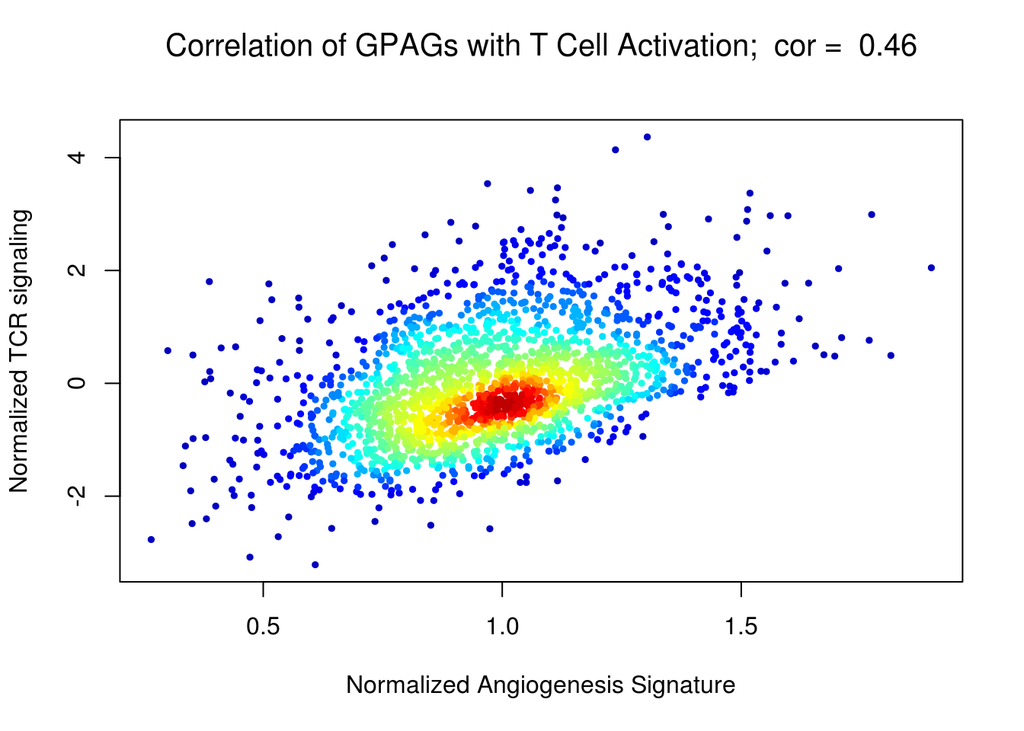

```r
TCR_sig <- rbind(data.frame(ang=apply(metabric.a.exp[, rownames(GPAGs)], 1, sum), TCR=apply(metabric.a.exp[, GO0042110], 1, sum), type="GPAGs"), data.frame(ang=apply(metabric.a.exp[, rownames(PPAGs)], 1, sum), TCR=apply(metabric.a.exp[, GO0042110], 1, sum), type="PPAGs"))
TCR_sig$norm_ang <- scale(TCR_sig$ang)
TCR_sig$norm_TCR <- scale(TCR_sig$TCR)

heatscatter(as.numeric(TCR_sig[TCR_sig$type=="GPAGs", "norm_ang"]), as.numeric(TCR_sig[TCR_sig$type=="GPAGs", "norm_TCR"]), colpal="bl2gr2rd", xlab="Normalized Angiogenesis Signature", ylab="Normalized TCR signaling", cor=TRUE, cex.main=1, main="Correlation of GPAGs with T Cell Activation;")
```

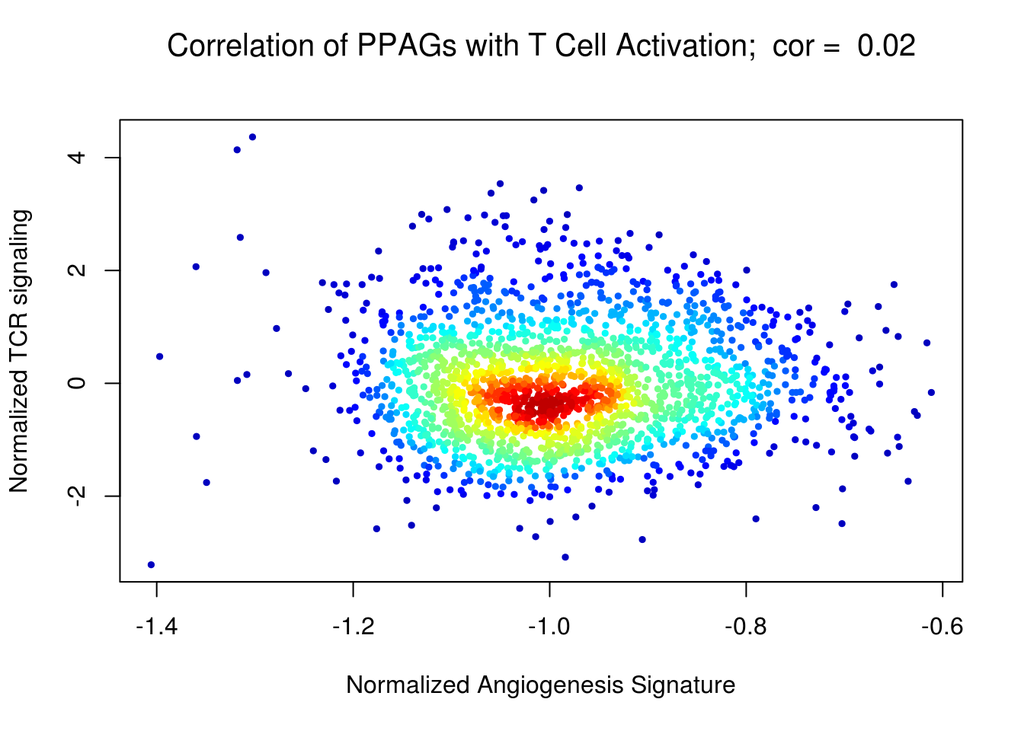

```r
heatscatter(as.numeric(TCR_sig[ TCR_sig$type=="PPAGs", "norm_ang"]), as.numeric(TCR_sig[TCR_sig$type=="PPAGs", "norm_TCR"]), colpal="bl2gr2rd", xlab="Normalized Angiogenesis Signature", ylab="Normalized TCR signaling", cor=TRUE, cex.main=1, main="Correlation of PPAGs with T Cell Activation;")
```